# Implementing EM for MNIST dataset, with low-rank approximation.

In this project, we will implement the EM algorithm for fitting a Gaussian mixture model for the same MNIST dataset, but use a different approach to deal with the high-dimensionality of data. We will use the so-called low-rank approximation, which can be viewed as performing PCA for each Gaussian component separately in the iterations. This question aims to demonstrate the principle of low-rank approximation for high-dimensional data, which is a very general principle in analyzing high-dimensional data.

Note that the pdf of the multivariate normal distribution is given by:

$$ \mathcal N(X|\mu, \Sigma) = \frac{1}{|\Sigma|^{1/2} (2\pi)^{d/2}} \exp\left\{- \frac 1 2 (X-\mu)^T \Sigma^{-1}(X-\mu) \right\}$$

Low-rank approximation of the covariance matrix $\Sigma$ means that we will represent it only using a relatively small number of eigenvectors (this corresponds to project the data into a low-dimensional subspace). For instance, the rank $r$ approximation to the covariance matrix is given by:

$$\Sigma \approx U \Lambda U^T$$

where $U \in \mathbb R^{n\times r}$ consists of the $r$-largest eigenvectors, $\Lambda \in \mathbb R^{r\times r}$ is a diagonal matrix consists of the corresponding $r$ largest eigenvalues $\{\lambda_1, \ldots, \lambda_r\}$.

Using this approximation, thus we can write the factors in the pdf of the multivariate normal as follows:

$$|\Sigma| \approx \prod_{i=1}^r \lambda_i$$

where $\lambda_i$'s are the eigenvalues ranked from the largest to the smallest. And

$$(X-\mu)^T \Sigma^{-1}(X-\mu) = \|\Lambda^{-1/2}U^T (X-\mu) \|^2$$

and thus, evaluating this quadratic term is really easy: we first compute the projection of data point after subtracting the mean $U^T (X-\mu)$ on to the subspace formed by $U$, and then evaluating $\Lambda^{-1/2} = \mbox{diag}\{\lambda_1^{-1/2}, \ldots, \lambda_r^{-1/2}\}$, and finally multiplying them together and find out the squared $\ell_2$ norm of the resulted vector.

The point is: the low-rank approximation will (i) avoid numerical errors by considering low-rank approximation to the original covariance matrix; and (ii) speeding up computation because the matrix operations are now down in a much smaller scale.

The low-rank structure's intuition is the following: high-dimensional data are usually lying close to a low-dimensional structure because they have similarity across the data points. In this example, all the hand-written digits 1 have similarities, and that's why they can be identified as 1. High-dimensional data rarely span the whole space (in that case, they tend to be meaningless or noise-like). So it is critical to find out the low-dimensional space that they actually lie on and perform the projection. Suppose we do not account for the low-dimensional structure in the data, in fact. In that case, we will run into numerical issues: the covariance matrix $\Sigma_k$ in the iteration of EM will be rank-deficient. It cannot be inverted (that's because they will have nearly zero eigenvalues and large condition numbers, in numerical linear algebra sense). This is also the reason in Question 2; we perform PCA as a pre-processing step to reduce dimensionality and avoid this issue. The low-dimensional approximation you will use here for this question will achieve better performance because you will perform an individualized low-rank approximation for each Gaussian component, which will more precisely account for the data structure.

The implementation of low rank approximated gaussian mixture modeling is in the collapsed cell below. The implementation covers primarily the same algorithm as the prior implementation as GMM above. However, instead of conducting PCA immediately on the dataset, we instead use PCA to reduce the dimensionality of the covariance matrix at each GMM refitting step. This allows us to hopefully reduce the cost incurred by large matrix operations such as determinants and matrix inversion while also enhancing numerical stability. This approach does come at the cost of less effective learning as PCA capture some but not all of the covariance matrix thus some of our ability to gain insight from that particular set of observations is lost.

```python
from __future__ import print_function
import numpy as np
import sklearn.preprocessing
from matplotlib.offsetbox import OffsetImage, AnnotationBbox
import matplotlib.pyplot as plt
import ipywidgets as widgets
from mpl_toolkits.mplot3d import axes3d
import matplotlib.pyplot as plt
import pandas as pd
from sklearn.decomposition import TruncatedSVD

mnist_labels = np.loadtxt('label.dat')
mnist_data = np.loadtxt('data.dat')

num_pcs = 5
original_mean = np.average(mnist_data,axis=1)[:,np.newaxis]
mnist_centered = mnist_data - original_mean
num_pix,num_images = mnist_centered.shape
cov_mnist =  np.dot(mnist_centered,mnist_centered.T) / (num_images)
U,Eigen_Vals,Vh = np.linalg.svd(cov_mnist)
k_eigvectors = U[:,0:num_pcs]
k_eigvals = Eigen_Vals[0:num_pcs]
mnist_pca = (np.dot(k_eigvectors.T,mnist_centered) / (np.sqrt(np.array(k_eigvals))[:,np.newaxis])).T
m,n = mnist_centered.shape
mnist_centered_cov = np.dot(mnist_centered,mnist_centered.T) / m

reduction = 10
K = 2
pi = np.random.random(K)

pi = pi/np.sum(pi)

mu = np.random.randn(K,mnist_centered.shape[0])
mu_old = mu.copy()

sigma = []

for i in range(K):
    inital_cov_i = np.random.randn(mnist_centered.shape[0],mnist_centered.shape[0])
    sigma.append(inital_cov_i @ inital_cov_i.T + np.identity(mnist_centered.shape[0]))

tau = np.full((mnist_pca.shape[0], K), fill_value=0.)

maxIter = 100
tolerance = 1e-3
log_likelihood2 = []
accuracy_list2 = []
stored_t2 = []


for i in range(maxIter):

    for ks in range(K):
        U_ks,Sigma_ks,Vh_ks = np.linalg.svd(sigma[ks])
        trunc = TruncatedSVD(n_components=reduction).fit(sigma[ks])
        U_ks_reduced =trunc.components_
        Sigma_ks_reduced = trunc.singular_values_

        fraction_piece = np.power(np.prod(Sigma_ks_reduced),-0.5)
        test = 1/Sigma_ks_reduced
        low_right = np.exp(-.5*np.power(np.linalg.norm((mnist_centered.T - mu[ks]) @ U_ks_reduced.T @ np.power(Sigma_ks_reduced[:,np.newaxis],-.5),axis=1),2))
        pdf = fraction_piece * low_right
        tau[:, ks] = pi[ks] * pdf


    sum_tau = np.sum(tau, axis=1)
    log_likelihood2.append(np.sum(np.log10(sum_tau)))
    sum_tau = sum_tau[:,np.newaxis]
    tau = np.divide(tau, np.tile(sum_tau, (1, K)))
    stored_t2.append(np.copy(tau))

    for ks2 in range(K):
        pi[ks2] = np.sum(tau[:, ks2])/ num_images
        mu[ks2] = mnist_centered @ tau[:,ks2] / np.sum(tau[:,ks2], axis=0)
        centered_ks = mnist_centered.T - np.tile(mu[ks2], (num_images,1))
        sigma[ks2] = centered_ks.T @ np.diag(tau[:,ks2]) @ centered_ks / np.sum(tau[:,ks2], axis=0)

    gmm_labels = np.argmax(tau,axis=1)
    gmm_labels1 = np.where(gmm_labels == 0,6,2)
    gmm_labels2 = np.where(gmm_labels == 0,2,6)
    number_of_samples = gmm_labels.shape[0]
    number_correct1 = np.sum(mnist_labels == gmm_labels1)
    number_correct2 = np.sum(mnist_labels == gmm_labels2)
    gmm_percent_correct1 = number_correct1/number_of_samples
    gmm_percent_correct2 = number_correct2/number_of_samples

    if gmm_percent_correct1 > gmm_percent_correct2:
        iteration_accuracy = gmm_percent_correct1
    else:
        iteration_accuracy = gmm_percent_correct2
    accuracy_list2.append(iteration_accuracy)

    if np.linalg.norm(mu-mu_old) < tolerance:

        break
    mu_old = mu.copy()
    if i==(maxIter-1):

        break
```

### Log Likelihood Plotted throughout various iterations of low rank approximated GMM:

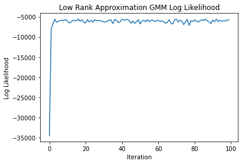

```python
plt.plot(log_likelihood2)
plt.title('Low Rank Approximation GMM Log Likelihood')
plt.xlabel('Iteration')
plt.ylabel('Log Likelihood')
plt.show()
```

As we can see from the plot above, the low rank approximation implementation of GMM does not follow the nice continuous convergence we saw above. Part of the reason for this apparent instability which allows the algorism to approach what appears to be a local maximum, but fails to truly converge is the fact that our reduction of the covariance matrix at each refitting step keeps the optimization unable to reach full convergence. It is conceivable that with enough iterations there could potentially be a point where the loglikelihood breaks out of this range. However, it could be very computationally expensive to approach such a point. For these reasons, the initial implementation of GMM is far better due to its optimization properties as well as its consistency.

### Low Rank Approximated GMM Reconstructed Mean Vectors:

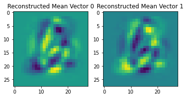

```python
mean_1_recon_red = np.reshape(mu[0],(28,28)).T
mean_2_recon_red = np.reshape(mu[1],(28,28)).T
plt.figure(figsize=(6,6))
plt.subplot(121)
plt.imshow(mean_1_recon_red)
plt.title('Reconstructed Mean Vector 0')
plt.subplot(122)
plt.imshow(mean_2_recon_red)
plt.title('Reconstructed Mean Vector 1')
plt.show()
```

As we can see from the reconstructed mean vectors which are illegible, our low rank approximated model has obviously done far worse at its learning task than that of the GMM implementation exhibited in Question 2. Given that our mean vectors output are very noisy and not obviously insightful it is doubtful our model will show any amount of significant performance at least of this specific initialization used as the for low rank approximation the initialization carries far more impact than with our previous GMM implementation.

### Low Rank Approximated GMM Plotted by PC0 and PC1 with True Labels:

```python
images_album = np.reshape(mnist_data,(28,28,1990))
images_album_index_2s = np.random.choice(np.where(mnist_labels == 2)[0],size=25)
images_album_index_6s = np.random.choice(np.where(mnist_labels == 6)[0],size=25)
images_album_index = np.concatenate((images_album_index_2s,images_album_index_6s),axis=0)
def color_pca_plot(iter_view):
    num_iter = len(stored_t2) -1
    red = stored_t2[iter_view][:,0][:,np.newaxis]
    blue = stored_t2[iter_view][:,1][:,np.newaxis]
    green = np.zeros(num_images)[:,np.newaxis]
    color_tau = np.concatenate((red,green,blue),axis=1)
    fig, ax = plt.subplots(figsize=(7,7))
    iso_pca = np.vstack((mnist_pca[:,0], mnist_pca[:,1]))
    ax.scatter(mnist_pca[:,0], mnist_pca[:,1], c=color_tau)
    ax.set_title('Low Rank Approx. GMM on Mnist Data Soft Cluster Labels by Iteration')
    ax.set_ylabel('Standardize PC 1')
    ax.set_xlabel('Standardize PC 0')
    for i in images_album_index:
        solo_image = images_album[:,:,i].T
        imagebox = OffsetImage(solo_image, zoom=0.7)
        ab = AnnotationBbox(imagebox, iso_pca.T[i], pad=0.01)
        ax.add_artist(ab)
widgets.interact(color_pca_plot,iter_view=widgets.IntSlider(min=0,max=len(stored_t2)-1,step=1,value=len(stored_t2)-1))
plt.show()
```

[output not shown]

### Classification Accuracy Plotted throughout various iterations of low rank approximated GMM:

Although the plots above indicate several problems with our low rank approach and likely signal trouble with the model, it is still important to examine accuracy and mis-match rates analytically as this will allow a more unbiased view into where and what types of errors our model is making. The results are shown below:

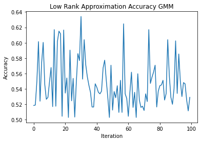

```
-------True Positive = 2 Classification Rate -------
0.4908456843940715
-------True Negative = 6 Classification Rate -------
0.44365361803084225
------- Precision Rate -------
0.5455426356589147
------- Negative Predictive Value Rate -------
0.3903966597077244
------- Accuracy Rate -------
0.4708542713567839
```

```python
plt.plot(accuracy_list2)
plt.title('Low Rank Approximation Accuracy GMM')
plt.xlabel('Iteration')
plt.ylabel('Accuracy')
plt.show()
gmm_labels_red = np.argmax(stored_t2[len(stored_t2)-1],axis=1)
gmm_labels_red = np.where(gmm_labels_red == 0,2,6)
from sklearn.metrics import confusion_matrix
confumat = confusion_matrix(mnist_labels,gmm_labels_red)
print('-------True Positive = 2 Classification Rate -------')
print(confumat[0,0] / (confumat[0,0] + confumat[1,0]))
print('-------True Negative = 6 Classification Rate -------')
print(confumat[1,1] / (confumat[1,1] + confumat[0,1]))
print('------- Precision Rate -------')
print(confumat[0,0] / (confumat[0,0] + confumat[0,1]))
print('------- Negative Predictive Value Rate -------')
print(confumat[1,1] / (confumat[1,1] + confumat[1,0]))
print('------- Accuracy Rate -------')
print((confumat[1,1] + confumat[0,0]) / (confumat[1,1] + confumat[0,1] + confumat[0,0] +confumat[1,0]))
```